© Bản quyền thuộc về Quantopian Inc.  
© Bản quyền sửa đổi thuộc về AI Cafe¹  
Giấy phép [Creative Commons Attribution 4.0](https://creativecommons.org/licenses/by/4.0/legalcode).  
[Khuyến cáo](https://aicafe.one/khuyen-cao/)

# Giới thiệu về môi trường Colab/Jupyter Notebooks

Colab/Jupyter notebooks (sau này gọi tắt là notebooks) cho phép người dùng thực hiện một lượng lớn phân tích dữ liệu và kiểm định thống kê. Chúng ta sẽ trình bày một vài kỹ thuật đơn giản ở đây.

## Code Cells vs. Text Cells

Như chúng ta thấy, có 2 loại cell trong notebooks

- **Code Cells**: Sử dụng để nhập vào dòng lệnh code thực thi lệnh, thường viết bằng ngôn ngữ lập trình Python
- **Text Cells**: Sử dụng cho việc nhập ngôn ngữ tự nhiên, lời diễn giải trong notebooks, sử dụng cấu trúc định dạng Markdown

## Thực thi một Lệnh

Một Code Cell sẽ được thực thi khi bạn nhấn nút chạy (run), hoặc khi bạn nhấn tổ hợp phím shift-enter. Việc thực thi một Code Cell sẽ thực hiện từng dòng mã theo thứ tự và in kết quả của dòng cuối cùng bên dưới ô đó.

```python
2 + 2
```

```
4
```

Đôi khi không có kết quả nào để in ra, như trường hợp với việc gán giá trị

```python
X = 2
```

Hãy nhớ rằng chỉ có kết quả từ dòng cuối cùng được in ra

```python
2 + 2
3 + 3
```

```
6
```

Tuy nhiên, bạn có thể in bất kỳ dòng nào bạn muốn bằng cách sử dụng câu lệnh *print*.

```python
print(2 + 2)
3 + 3
```

```
4
```

```
6
```

## Nhận biết Cell đang chạy

Khi một ô đang chạy, một `[*]` (hoặc biểu tượng quay quay) sẽ hiển thị ở bên trái. Khi ô đó chưa được thực hiện, sẽ hiển thị `[ ]`. Khi nó đã được chạy, một số sẽ hiển thị để chỉ ra thứ tự mà nó đã được thực hiện trong quá trình chạy notebooks `[5]`. Hãy thử trên ô này và ghi chú lại điều đó.

```python
# Take some time to run something
c = 0
for i in range(10000000):
    c = c + i
c
```

```
49999995000000
```

## Import các thư viện

Hầu hết thời gian, bạn sẽ muốn sử dụng các hàm từ các thư viện đã được xây dựng sẵn. Ở đây, tôi nhập vào `numpy` và `pandas`, hai thư viện phổ biến và hữu ích nhất trong tài chính định lượng. Bạn nên sao chép câu lệnh nhập này vào mỗi sổ tay mới.

Lưu ý rằng bạn có thể đổi tên các thư viện thành bất cứ tên gì bạn muốn sau khi nhập. Câu lệnh `as` cho phép điều này. Ở đây, chúng tôi sử dụng `np` và `pd` làm bí danh cho `numpy` và `pandas`. Đây là một bí danh rất phổ biến và sẽ được tìm thấy trong hầu hết các đoạn code trên mạng. Mục đích của điều này là để bạn có thể gõ ít ký tự hơn khi bạn thường xuyên truy cập vào các thư viện này.

```python
import numpy as np
import pandas as pd

# This is a plotting library for pretty pictures.
import matplotlib.pyplot as plt
```

## Viết code tự động với AI

Khi viết code vào trong Code Cell trên Google Colab, bạn sẽ thấy lượng code mờ mờ được gợi ý ra cho bạn. Khi này, chỉ cần nhấn `Tab` hoặc `Enter` để chấp nhận gợi ý, nhấn `Esc` để từ chối gợi ý. Thử nhấn thêm `.` vào dưới cell này để xem gợi ý

```python
plt
```

```
<module 'matplotlib.pyplot' from '/usr/local/lib/python3.11/dist-packages/matplotlib/pyplot.py'>
```

## Xem tài liệu của một hàm

Đặt dấu hỏi sau một hàm và thực thi dòng code đó sẽ cung cấp cho bạn tài liệu mà Python có cho hàm đó. Thường thì tốt nhất là làm điều này trong một Cell mới, vì bạn sẽ tránh việc thực thi lại mã khác và gặp phải các lỗi.

```python
np.random.normal?
```

## Sampling (lấy mẫu)

Chúng ta sẽ lấy mẫu giá trị ngẫu nhiên bởi hàm chức năng trong `numpy`.

```python
# Sample 100 points with a mean of 0 and an std of 1. This is a standard normal distribution.
X = np.random.normal(0, 1, 100)
```

## Vẽ biểu đồ

Sử dụng thư viện `matplotlib` để biểu diễn dữ liệu dưới dạng hình ảnh

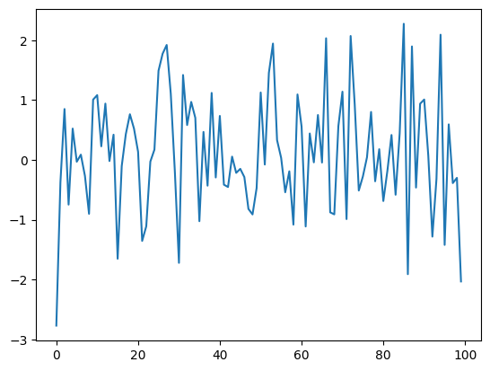

```python
plt.plot(X)
```

### Dòng xuất hiện gây khó chịu

Bạn có thể đã nhận thấy dòng khó chịu có dạng [<matplotlib.lines.Line2D at 0x7...>] trước các đồ thị. Điều này xảy ra vì hàm .plot thực sự tạo ra đầu ra. Đôi khi chúng ta không muốn hiển thị đầu ra, chúng ta có thể thực hiện điều này bằng cách sử dụng dấu chấm phẩy như sau.

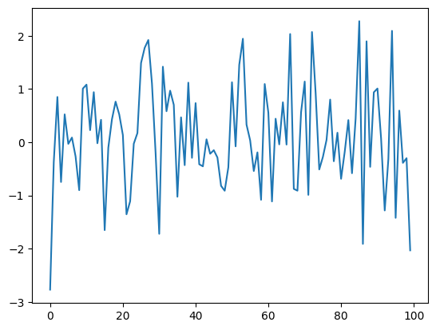

```python
plt.plot(X);
```

### Thêm nhãn cho biểu đồ

Không có nhà định lượng nào tự tôn lại bỏ qua việc ghi nhãn trục trên biểu đồ. Dưới đây là một số lệnh để giúp bạn làm điều đó.

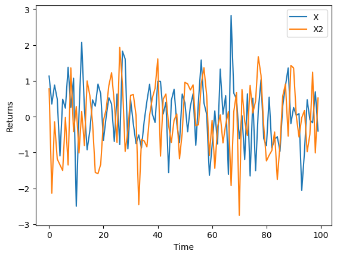

```python
X = np.random.normal(0, 1, 100)
X2 = np.random.normal(0, 1, 100)

plt.plot(X);
plt.plot(X2);
plt.xlabel('Time') # The data we generated is unitless, but don't forget units in general.
plt.ylabel('Returns')
plt.legend(['X', 'X2']);
```

## Thống kê mô tả

Sử dụng `numpy` để tính một số giá trị thống kê dữ liệu

```python
np.mean(X)
```

```
np.float64(0.0666676250773496)
```

```python
np.std(X)
```

```
np.float64(0.8991089428492867)
```

## Làm việc với dữ liệu thật

Dữ liệu được lấy mẫu ngẫu nhiên có thể rất tốt để thử nghiệm ý tưởng, nhưng hãy lấy một số dữ liệu thực tế.

Với dữ liệu chứng khoán Việt Nam, chúng ta có thể lấy từ một số nguồn miễn phí như CafeF (https://cafef.vn/du-lieu/du-lieu-download.chn#data) để tiến hành phân tích.

Ở đây, AI Cafe¹ có tạo một thư viện để giúp các bạn lấy dữ liệu miễn phí về phân tích. Sử dụng câu lệnh dưới đây để cài đặt thư viện

```python
# Cài thư viện lấy dữ liệu miễn phí
!curl -fsSLO https://raw.githubusercontent.com/algo-stocks/data/master/data.py
```

Trước khi sử dụng, chúng ta cần `import` thư viện vào môi trường làm việc

```python
from data import get_pricing, get_prices
```

Hàm `get_pricing` sử dụng để lấy dữ liệu cho từng cổ phiếu, còn hàm `get_prices` được sử dụng để lấy dữ liệu cho nhiều cổ phiếu cùng một lúc

```python
data = get_pricing('FPT')
```

Đây là một pandas dataframe, chúng ta có thể xem một phần dữ liệu của dataframe này

```python
data.head()
```

| date | ticker | open | high | low | close | volume |
| --- | --- | --- | --- | --- | --- | --- |
| 2006-12-13 | FPT | 11.4000 | 11.4000 | 11.4000 | 11.4372 | 83530 |
| 2006-12-13 | FPT | 11.4000 | 11.4000 | 11.4000 | 11.4372 | 83530 |
| 2006-12-14 | FPT | 11.9700 | 11.9700 | 11.9700 | 12.0091 | 280710 |
| 2006-12-14 | FPT | 11.9700 | 11.9700 | 11.9700 | 12.0091 | 280710 |
| 2006-12-15 | FPT | 12.5685 | 12.5685 | 12.5685 | 12.6095 | 265300 |

Với dataframe này, chúng ta có thể chỉ lấy giá đóng cửa của cổ phiếu. Thông tin thêm về `pandas`, xem [tại đây](http://pandas.pydata.org/pandas-docs/stable/10min.html).

```python
X = data['close']
```

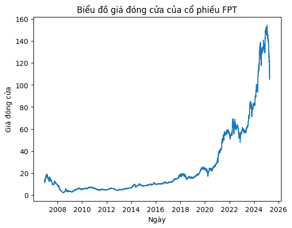

```python
plt.plot(X.index, X.values)
plt.ylabel('Giá đóng cửa')
plt.xlabel('Ngày')
plt.title('Biểu đồ giá đóng cửa của cổ phiếu FPT');
```

Một số thống kê từ dữ liệu thực tế

```python
np.mean(X)
```

```
np.float64(26.06903489628349)
```

```python
np.std(X)
```

```
32.67350502299331
```

## Tính Returns từ giá

Chúng ta dùng hàm `pct_change` để tính returns. Lưu ý rằng chúng ta bỏ phần tử đầu tiên sau khi thực hiện điều này, vì nó sẽ là NaN (không có gì -> điều gì đó dẫn đến sự thay đổi phần trăm NaN).

```python
R = X.pct_change()[1:]
```

Biểu diễn returns dưới dạng histogram.

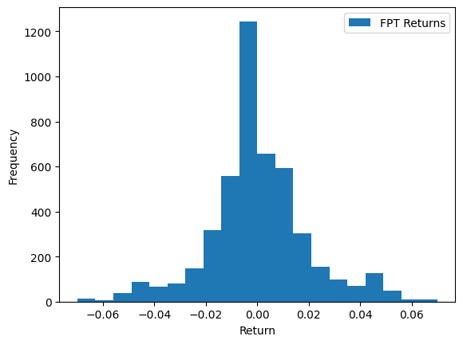

```python
plt.hist(R, bins=20)
plt.xlabel('Return')
plt.ylabel('Frequency')
plt.legend(['FPT Returns']);
```

Tính lại một số giá trị thống kê

```python
np.mean(R)
```

```
np.float64(0.0006897680628880074)
```

```python
np.std(R)
```

```
0.019210044580913663
```

Bây giờ hãy quay ngược lại và tạo ra dữ liệu từ một phân phối chuẩn dựa trên các thống kê mà chúng ta ước lượng từ lợi nhuận của FPT. Chúng ta sẽ thấy rằng có lý do chính đáng để nghi ngờ rằng lợi nhuận của FPT có thể không theo phân phối chuẩn, vì phân phối chuẩn kết quả trông rất khác biệt.

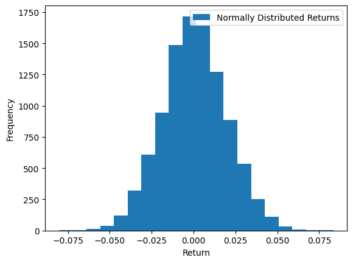

```python
plt.hist(np.random.normal(np.mean(R), np.std(R), 10000), bins=20)
plt.xlabel('Return')
plt.ylabel('Frequency')
plt.legend(['Normally Distributed Returns']);
```

## Tính đường trung bình động

`pandas` có một số công cụ tuyệt vời cho phép chúng ta tạo ra các thống kê động. Đây là một ví dụ. Chú ý rằng không có trung bình động cho 60 ngày đầu tiên, vì chúng ta không có 60 ngày dữ liệu để tạo ra thống kê này.

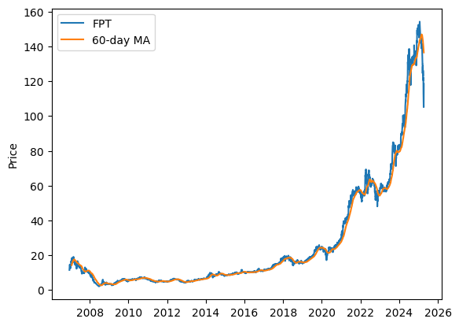

```python
# Take the average of the last 60 days at each timepoint.
MA = X.rolling(window=60).mean()
plt.plot(X.index, X.values)
plt.plot(MA.index, MA.values)
plt.ylabel('Price')
plt.legend(['FPT', '60-day MA']);
```

*Lưu ý: Tài liệu này mang tính chất chia sẻ kiến thức khoa học dữ liệu. Các mã chứng khoán xuất hiện trong tài liệu chỉ mang tính chất minh hoạ, không khuyến nghị đầu tư. Chúng tôi không chịu trách nhiệm trước mọi rủi ro nào do sử dụng tài liệu này.*